# Mixed models for CS paper 2, all data

2024-01-19

## GLMMs from January 2024

I am coming back to this after several months away. I think I need to analyze each question using GLMM, with phylum_class as a random effect. I think I understand the syntax here, which is this:

summary(glmer(CSss~Eco_diff+(1|phylum_class),data=surveymorpho,family=binomial))

The probability of a species having CSss based on Eco_diff, once the variance from phylum_class is accounted for.

So, game plan: build a model and then work through the table with it.

First, code to load libraries, read in files, etc

1. Taxonomic work is needed? Are there more CSss or CSsl overall? This can probably stay the same, chi-square test.

```
##
##  Pearson's Chi-squared test with Yates' continuity correction
##
## data:  cbind(expected, observed)
## X-squared = 24.723, df = 1, p-value = 6.619e-07
```

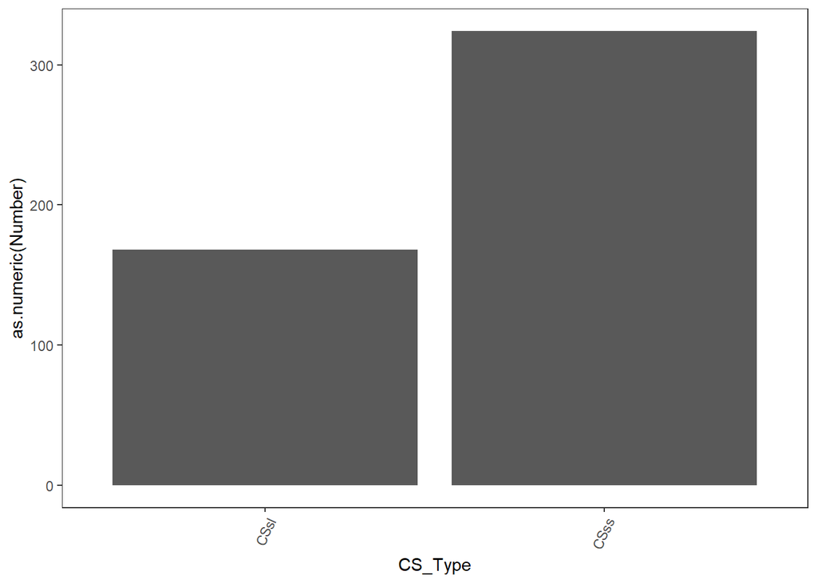

More CSss than the 50% benchmark (significant), so reject the idea that most CS are just due to taxonomic oversight. BUT, does this vary with phyla or classes?

```
## Single term deletions
##
## Model:
## CSss ~ phylum_wormsV1
##                Df Deviance    AIC    LRT Pr(>Chi)
## <none>              612.48 642.48
## phylum_wormsV1 14   631.73 633.73 19.249   0.1557
```

```
## Single term deletions
##
## Model:
## CSss ~ class_wormsV1
##               Df Deviance    AIC    LRT  Pr(>Chi)
## <none>             548.08 628.08
## class_wormsV1 39   623.60 625.60 75.517 0.0004055 ***
## ---
## Signif. codes:  0 '***' 0.001 '**' 0.01 '*' 0.05 '.' 0.1 ' ' 1
```

```
## Single term deletions
##
## Model:
## CSss ~ phylum_class
##              Df Deviance    AIC    LRT  Pr(>Chi)
## <none>            549.38 635.38
## phylum_class 42   631.73 633.73 82.354 0.0001979 ***
## ---
## Signif. codes:  0 '***' 0.001 '**' 0.01 '*' 0.05 '.' 0.1 ' ' 1
```

Phylum is not significant, but class is (both class_wormsV1 and phylum_class). This is because of a few classes, mostly Ascidea (others are minor classes, ie <10 species). So, from here I will be using mixed models with phylum_class as a random factor. This will *remove variation due to phylum_class* and allow us to see if there is a main effect once phylum_class is accounted for. This is not a proper phylo correction per se but should get the job done.

2. Are there differences in time of description? For this, the independent variable is time (year of description OR decade of description; not sure why we need to bin but I will run both of them). Dependent variable is CSss.

```
## Generalized linear mixed model fit by maximum likelihood (Laplace
##   Approximation) [glmerMod]
##  Family: binomial  ( logit )
## Formula: CSss ~ decade + (1 | phylum_class)
##    Data: surveymorpho
##
##      AIC      BIC   logLik deviance df.resid
##    550.1    662.9   -247.0    494.1      387
##
## Scaled residuals:
##     Min      1Q  Median      3Q     Max
## -3.6639 -0.9388  0.4680  0.6979  1.9937
##
## Random effects:
##  Groups       Name        Variance Std.Dev.
##  phylum_class (Intercept) 0.5113   0.715
## Number of obs: 415, groups:  phylum_class, 41
##
## Fixed effects:
##             Estimate Std. Error z value Pr(>|z|)
## (Intercept)  0.70146    0.53727   1.306   0.1917
## decade1770   0.15120    0.81507   0.186   0.8528
## decade1780   0.82260    0.95374   0.863   0.3884
## decade1790  -0.86605    0.91533  -0.946   0.3441
## decade1800   1.97343    1.16978   1.687   0.0916 .
## decade1810  -1.38065    0.79364  -1.740   0.0819 .
## decade1820  -0.25268    0.75825  -0.333   0.7390
## decade1830  -0.57851    0.65601  -0.882   0.3779
## decade1840  -0.50099    0.66675  -0.751   0.4524
## decade1850   0.16644    0.67643   0.246   0.8056
## decade1860  -0.42001    0.76372  -0.550   0.5823
## decade1870  -0.43422    0.66909  -0.649   0.5164
## decade1880  -0.03201    0.72735  -0.044   0.9649
## decade1890  -0.46197    0.80828  -0.572   0.5676
## decade1900   0.53913    0.86465   0.624   0.5329
## decade1910   2.15711    1.18805   1.816   0.0694 .
## decade1920  -0.37760    1.04635  -0.361   0.7182
## decade1930  -0.39618    0.85466  -0.464   0.6430
## decade1940  -1.21309    0.83336  -1.456   0.1455
## decade1950  -0.25444    1.36823  -0.186   0.8525
## decade1960   1.34971    1.23259   1.095   0.2735
## decade1970  -1.75899    1.04746  -1.679   0.0931 .
## decade1980   0.22930    0.90405   0.254   0.7998
## decade1990   0.89915    0.97110   0.926   0.3545
## decade2000  -0.12298    0.80820  -0.152   0.8791
## decade2010   0.39591    0.68820   0.575   0.5651
## decade2020  -0.11368    0.64664  -0.176   0.8605
## ---
## Signif. codes:  0 '***' 0.001 '**' 0.01 '*' 0.05 '.' 0.1 ' ' 1
## optimizer (Nelder_Mead) convergence code: 0 (OK)
## Model failed to converge with max|grad| = 0.00490098 (tol = 0.002, component 1)
```

```
## Generalized linear mixed model fit by maximum likelihood (Laplace
##   Approximation) [glmerMod]
##  Family: binomial  ( logit )
## Formula: CSss ~ yearb + (1 | phylum_class)
##    Data: surveymorpho
##
##      AIC      BIC   logLik deviance df.resid
##    538.1    550.2   -266.1    532.1      412
##
## Scaled residuals:
##     Min      1Q  Median      3Q     Max
## -1.9167 -1.0852  0.5701  0.7388  1.1237
##
## Random effects:
##  Groups       Name        Variance Std.Dev.
##  phylum_class (Intercept) 0.4049   0.6363
## Number of obs: 415, groups:  phylum_class, 41
##
## Fixed effects:
##               Estimate Std. Error z value Pr(>|z|)
## (Intercept) -1.0217218  2.1249649  -0.481    0.631
## yearb        0.0008689  0.0011261   0.772    0.440
##
## Correlation of Fixed Effects:
##       (Intr)
## yearb -0.996
## optimizer (Nelder_Mead) convergence code: 0 (OK)
## Model failed to converge with max|grad| = 0.0635708 (tol = 0.002, component 1)
## Model is nearly unidentifiable: very large eigenvalue
##  - Rescale variables?
## Model is nearly unidentifiable: large eigenvalue ratio
##  - Rescale variables?
```

So no effect of time on CSss, either by year (continuous) or decade (bins).

3. Are there differences in the number that are easy or hard to access through time? First, test trend in HARD to access through time:

```
## Generalized linear mixed model fit by maximum likelihood (Laplace
##   Approximation) [glmerMod]
##  Family: binomial  ( logit )
## Formula: Difficult ~ yearb + (1 | phylum_class)
##    Data: surveyaccess
##
##      AIC      BIC   logLik deviance df.resid
##    544.5    558.7   -269.3    538.5      830
##
## Scaled residuals:
##     Min      1Q  Median      3Q     Max
## -0.8243 -0.3683 -0.2557 -0.1867  6.8326
##
## Random effects:
##  Groups       Name        Variance Std.Dev.
##  phylum_class (Intercept) 1.379    1.175
## Number of obs: 833, groups:  phylum_class, 45
##
## Fixed effects:
##               Estimate Std. Error z value Pr(>|z|)
## (Intercept) -1.544e+01  1.540e+00 -10.027   <2e-16 ***
## yearb        6.727e-03  7.947e-04   8.465   <2e-16 ***
## ---
## Signif. codes:  0 '***' 0.001 '**' 0.01 '*' 0.05 '.' 0.1 ' ' 1
##
## Correlation of Fixed Effects:
##       (Intr)
## yearb -0.969
## optimizer (Nelder_Mead) convergence code: 0 (OK)
## Model failed to converge with max|grad| = 0.046852 (tol = 0.002, component 1)
## Model is nearly unidentifiable: very large eigenvalue
##  - Rescale variables?
## Model is nearly unidentifiable: large eigenvalue ratio
##  - Rescale variables?
```

So there IS a trend where Difficult Access CS are described later. How about easy?

```
## Generalized linear mixed model fit by maximum likelihood (Laplace
##   Approximation) [glmerMod]
##  Family: binomial  ( logit )
## Formula: Easy ~ yearb + (1 | phylum_class)
##    Data: surveyaccess
##
##      AIC      BIC   logLik deviance df.resid
##    764.2    778.4   -379.1    758.2      830
##
## Scaled residuals:
##     Min      1Q  Median      3Q     Max
## -0.9769 -0.5137 -0.3571 -0.2603  3.9045
##
## Random effects:
##  Groups       Name        Variance Std.Dev.
##  phylum_class (Intercept) 1.013    1.007
## Number of obs: 833, groups:  phylum_class, 45
##
## Fixed effects:
##              Estimate Std. Error z value Pr(>|z|)
## (Intercept)  3.470069   2.076215   1.671   0.0947 .
## yearb       -0.002680   0.001117  -2.400   0.0164 *
## ---
## Signif. codes:  0 '***' 0.001 '**' 0.01 '*' 0.05 '.' 0.1 ' ' 1
##
## Correlation of Fixed Effects:
##       (Intr)
## yearb -0.994
## optimizer (Nelder_Mead) convergence code: 0 (OK)
## Model failed to converge with max|grad| = 0.154402 (tol = 0.002, component 1)
## Model is nearly unidentifiable: very large eigenvalue
##  - Rescale variables?
## Model is nearly unidentifiable: large eigenvalue ratio
##  - Rescale variables?
```

…and where easy ones are described earlier.

4. How about HKK (habitat connectivity) and an association with CSss?

```
## Generalized linear mixed model fit by maximum likelihood (Laplace
##   Approximation) [glmerMod]
##  Family: binomial  ( logit )
## Formula: CSss ~ HKKv3 + (1 | phylum_class)
##    Data: surveymorpho
##
##      AIC      BIC   logLik deviance df.resid
##    581.5    593.8   -287.7    575.5      449
##
## Scaled residuals:
##     Min      1Q  Median      3Q     Max
## -2.3029 -1.1119  0.6233  0.7640  1.1755
##
## Random effects:
##  Groups       Name        Variance Std.Dev.
##  phylum_class (Intercept) 0.3137   0.5601
## Number of obs: 452, groups:  phylum_class, 42
##
## Fixed effects:
##              Estimate Std. Error z value Pr(>|z|)
## (Intercept) 0.5222582  0.1731721   3.016  0.00256 **
## HKKv3       0.0008152  0.0004124   1.977  0.04806 *
## ---
## Signif. codes:  0 '***' 0.001 '**' 0.01 '*' 0.05 '.' 0.1 ' ' 1
##
## Correlation of Fixed Effects:
##       (Intr)
## HKKv3 -0.320
## optimizer (Nelder_Mead) convergence code: 0 (OK)
## Model failed to converge with max|grad| = 0.00249359 (tol = 0.002, component 1)
## Model is nearly unidentifiable: very large eigenvalue
##  - Rescale variables?
```

Slight effect of HKKv3, with a positive effect (large HKK more likely to show more CSss).

5. Is habitat stability associated with CSss?

```
## Generalized linear mixed model fit by maximum likelihood (Laplace
##   Approximation) [glmerMod]
##  Family: binomial  ( logit )
## Formula: CSss ~ Hstable + (1 | phylum_class)
##    Data: surveymorpho
##
##      AIC      BIC   logLik deviance df.resid
##    628.4    641.0   -311.2    622.4      489
##
## Scaled residuals:
##     Min      1Q  Median      3Q     Max
## -1.8999 -1.1919  0.5968  0.7160  1.0237
##
## Random effects:
##  Groups       Name        Variance Std.Dev.
##  phylum_class (Intercept) 0.2504   0.5004
## Number of obs: 492, groups:  phylum_class, 43
##
## Fixed effects:
##             Estimate Std. Error z value Pr(>|z|)
## (Intercept)   0.5857     0.1693   3.460  0.00054 ***
## HstableTRUE   0.3105     0.2121   1.464  0.14329
## ---
## Signif. codes:  0 '***' 0.001 '**' 0.01 '*' 0.05 '.' 0.1 ' ' 1
##
## Correlation of Fixed Effects:
##             (Intr)
## HstableTRUE -0.452
```

No effect of habitat stability with these habitat classes.

6. Are CSss more common in sympatry or not?

```
## Generalized linear mixed model fit by maximum likelihood (Laplace
##   Approximation) [glmerMod]
##  Family: binomial  ( logit )
## Formula: CSss ~ Sympatric + (1 | phylum_class)
##    Data: surveymorpho
##
##      AIC      BIC   logLik deviance df.resid
##    611.9    624.5   -303.0    605.9      483
##
## Scaled residuals:
##     Min      1Q  Median      3Q     Max
## -2.1845 -1.1038  0.5460  0.7155  1.0469
##
## Random effects:
##  Groups       Name        Variance Std.Dev.
##  phylum_class (Intercept) 0.2389   0.4888
## Number of obs: 486, groups:  phylum_class, 43
##
## Fixed effects:
##               Estimate Std. Error z value Pr(>|z|)
## (Intercept)     1.1725     0.2125   5.517 3.46e-08 ***
## SympatricTRUE  -0.6869     0.2137  -3.214  0.00131 **
## ---
## Signif. codes:  0 '***' 0.001 '**' 0.01 '*' 0.05 '.' 0.1 ' ' 1
##
## Correlation of Fixed Effects:
##             (Intr)
## SymptrcTRUE -0.703
```

CSss are LESS common in sympatry, which matches predictions (sympatric species have diagnostic diffs).

7. Are species in sympatry more likely to have ecological differentiation?

```
## Generalized linear mixed model fit by maximum likelihood (Laplace
##   Approximation) [glmerMod]
##  Family: binomial  ( logit )
## Formula: Eco_diff ~ Sympatric + (1 | phylum_class)
##    Data: survey
##
##      AIC      BIC   logLik deviance df.resid
##    157.4    166.4    -75.7    151.4      145
##
## Scaled residuals:
##     Min      1Q  Median      3Q     Max
## -2.0354  0.4913  0.4913  0.4913  0.5774
##
## Random effects:
##  Groups       Name        Variance  Std.Dev.
##  phylum_class (Intercept) 8.275e-16 2.877e-08
## Number of obs: 148, groups:  phylum_class, 27
##
## Fixed effects:
##               Estimate Std. Error z value Pr(>|z|)
## (Intercept)     1.0986     0.3651   3.009  0.00262 **
## SympatricTRUE   0.3228     0.4387   0.736  0.46187
## ---
## Signif. codes:  0 '***' 0.001 '**' 0.01 '*' 0.05 '.' 0.1 ' ' 1
##
## Correlation of Fixed Effects:
##             (Intr)
## SymptrcTRUE -0.832
## optimizer (Nelder_Mead) convergence code: 0 (OK)
## boundary (singular) fit: see help('isSingular')
```

No, no relation

8. Are CSss more likely in species with eco diff?

```
## Generalized linear mixed model fit by maximum likelihood (Laplace
##   Approximation) [glmerMod]
##  Family: binomial  ( logit )
## Formula: CSss ~ Eco_diff + (1 | phylum_class)
##    Data: surveymorpho
##
##      AIC      BIC   logLik deviance df.resid
##    128.8    136.9    -61.4    122.8      104
##
## Scaled residuals:
##     Min      1Q  Median      3Q     Max
## -2.1714 -1.0158  0.4605  0.6387  0.9874
##
## Random effects:
##  Groups       Name        Variance Std.Dev.
##  phylum_class (Intercept) 0.503    0.7092
## Number of obs: 107, groups:  phylum_class, 24
##
## Fixed effects:
##             Estimate Std. Error z value Pr(>|z|)
## (Intercept)   2.0688     0.6704   3.086  0.00203 **
## Eco_diffYes  -1.5193     0.6840  -2.221  0.02634 *
## ---
## Signif. codes:  0 '***' 0.001 '**' 0.01 '*' 0.05 '.' 0.1 ' ' 1
##
## Correlation of Fixed Effects:
##             (Intr)
## Eco_diffYes -0.895
```

Species with ecological differentiation are LESS likely to be CSss (more likely to have diagnostic differences).

9. Biological traits associated with CSss?

```
## Generalized linear mixed model fit by maximum likelihood (Laplace
##   Approximation) [glmerMod]
##  Family: binomial  ( logit )
## Formula: CSss ~ hard_skeleton + (1 | phylum_class)
##    Data: surveymorpho
##
##      AIC      BIC   logLik deviance df.resid
##    597.3    609.7   -295.6    591.3      461
##
## Scaled residuals:
##     Min      1Q  Median      3Q     Max
## -1.9032 -1.1096  0.5773  0.7634  0.9510
##
## Random effects:
##  Groups       Name        Variance Std.Dev.
##  phylum_class (Intercept) 0.2719   0.5215
## Number of obs: 464, groups:  phylum_class, 39
##
## Fixed effects:
##                Estimate Std. Error z value Pr(>|z|)
## (Intercept)      0.9118     0.2812   3.243  0.00118 **
## hard_skeletonY  -0.3557     0.3428  -1.038  0.29946
## ---
## Signif. codes:  0 '***' 0.001 '**' 0.01 '*' 0.05 '.' 0.1 ' ' 1
##
## Correlation of Fixed Effects:
##             (Intr)
## hard_skltnY -0.822
```

```
## Generalized linear mixed model fit by maximum likelihood (Laplace
##   Approximation) [glmerMod]
##  Family: binomial  ( logit )
## Formula: CSss ~ ferti + (1 | phylum_class)
##    Data: surveymorpho
##
##      AIC      BIC   logLik deviance df.resid
##    598.4    614.9   -295.2    590.4      460
##
## Scaled residuals:
##     Min      1Q  Median      3Q     Max
## -1.7939 -1.2097  0.5646  0.7251  1.0472
##
## Random effects:
##  Groups       Name        Variance Std.Dev.
##  phylum_class (Intercept) 0.1889   0.4346
## Number of obs: 464, groups:  phylum_class, 39
##
## Fixed effects:
##             Estimate Std. Error z value Pr(>|z|)
## (Intercept)   0.3321     0.3391   0.979    0.327
## fertiE        0.5330     0.3890   1.370    0.171
## fertiI        0.1985     0.4729   0.420    0.675
##
## Correlation of Fixed Effects:
##        (Intr) fertiE
## fertiE -0.851
## fertiI -0.771  0.642
```

```
## Generalized linear mixed model fit by maximum likelihood (Laplace
##   Approximation) [glmerMod]
##  Family: binomial  ( logit )
## Formula: CSss ~ genitals + (1 | phylum_class)
##    Data: surveymorpho
##
##      AIC      BIC   logLik deviance df.resid
##    599.3    615.8   -295.6    591.3      460
##
## Scaled residuals:
##     Min      1Q  Median      3Q     Max
## -1.7480 -1.1816  0.5749  0.7428  0.9035
##
## Random effects:
##  Groups       Name        Variance Std.Dev.
##  phylum_class (Intercept) 0.1864   0.4317
## Number of obs: 464, groups:  phylum_class, 39
##
## Fixed effects:
##             Estimate Std. Error z value Pr(>|z|)
## (Intercept)  0.39876    0.49083   0.812    0.417
## genitalsN    0.38638    0.52283   0.739    0.460
## genitalsY    0.02626    0.58537   0.045    0.964
##
## Correlation of Fixed Effects:
##           (Intr) gntlsN
## genitalsN -0.939
## genitalsY -0.838  0.779
```

```
## Generalized linear mixed model fit by maximum likelihood (Laplace
##   Approximation) [glmerMod]
##  Family: binomial  ( logit )
## Formula: CSss ~ image + (1 | phylum_class)
##    Data: surveymorpho
##
##      AIC      BIC   logLik deviance df.resid
##    598.2    610.6   -296.1    592.2      461
##
## Scaled residuals:
##     Min      1Q  Median      3Q     Max
## -1.7974 -1.1105  0.5738  0.7416  0.9985
##
## Random effects:
##  Groups       Name        Variance Std.Dev.
##  phylum_class (Intercept) 0.2847   0.5336
## Number of obs: 464, groups:  phylum_class, 39
##
## Fixed effects:
##             Estimate Std. Error z value Pr(>|z|)
## (Intercept)   0.7171     0.1958   3.663 0.000249 ***
## imageY       -0.1342     0.3467  -0.387 0.698703
## ---
## Signif. codes:  0 '***' 0.001 '**' 0.01 '*' 0.05 '.' 0.1 ' ' 1
##
## Correlation of Fixed Effects:
##        (Intr)
## imageY -0.565
```

10. Ok, now larvae.

```
## Generalized linear mixed model fit by maximum likelihood (Laplace
##   Approximation) [glmerMod]
##  Family: binomial  ( logit )
## Formula: CSss ~ Repro_invest + (1 | phylum_class)
##    Data: surveylarvmorpho
##
##      AIC      BIC   logLik deviance df.resid
##    376.4    387.5   -185.2    370.4      292
##
## Scaled residuals:
##     Min      1Q  Median      3Q     Max
## -1.7813 -1.2092  0.5732  0.6910  0.9808
##
## Random effects:
##  Groups       Name        Variance Std.Dev.
##  phylum_class (Intercept) 0.2636   0.5135
## Number of obs: 295, groups:  phylum_class, 42
##
## Fixed effects:
##                 Estimate Std. Error z value Pr(>|z|)
## (Intercept)      0.72605    0.22070   3.290    0.001 **
## Repro_investLOW -0.01092    0.29151  -0.037    0.970
## ---
## Signif. codes:  0 '***' 0.001 '**' 0.01 '*' 0.05 '.' 0.1 ' ' 1
##
## Correlation of Fixed Effects:
##             (Intr)
## Rpr_nvstLOW -0.598
```

```
## Generalized linear mixed model fit by maximum likelihood (Laplace
##   Approximation) [glmerMod]
##  Family: binomial  ( logit )
## Formula: CSss ~ Larv_type + (1 | phylum_class)
##    Data: surveylarvmorpho
##
##      AIC      BIC   logLik deviance df.resid
##    372.7    387.4   -182.4    364.7      288
##
## Scaled residuals:
##     Min      1Q  Median      3Q     Max
## -1.9163 -1.2082  0.5684  0.6936  1.0485
##
## Random effects:
##  Groups       Name        Variance Std.Dev.
##  phylum_class (Intercept) 0.2241   0.4734
## Number of obs: 292, groups:  phylum_class, 42
##
## Fixed effects:
##             Estimate Std. Error z value Pr(>|z|)
## (Intercept)   0.9430     0.2875   3.280  0.00104 **
## Larv_typeLT  -0.5358     0.3977  -1.347  0.17793
## Larv_typePT  -0.1634     0.3347  -0.488  0.62527
## ---
## Signif. codes:  0 '***' 0.001 '**' 0.01 '*' 0.05 '.' 0.1 ' ' 1
##
## Correlation of Fixed Effects:
##             (Intr) Lrv_LT
## Larv_typeLT -0.658
## Larv_typePT -0.733  0.525
```

No effect of larval type (3 categories) or reproductive investment (2 categories).

11. Sediment vs rocky only

```
## Generalized linear mixed model fit by maximum likelihood (Laplace
##   Approximation) [glmerMod]
##  Family: binomial  ( logit )
## Formula: CSss ~ Hsubstrate + (1 | phylum_class)
##    Data: surveysed
##
##      AIC      BIC   logLik deviance df.resid
##    281.5    291.8   -137.7    275.5      224
##
## Scaled residuals:
##     Min      1Q  Median      3Q     Max
## -1.8099 -1.1580  0.5525  0.8636  0.8636
##
## Random effects:
##  Groups       Name        Variance Std.Dev.
##  phylum_class (Intercept) 0        0
## Number of obs: 227, groups:  phylum_class, 31
##
## Fixed effects:
##                    Estimate Std. Error z value Pr(>|z|)
## (Intercept)          0.2933     0.1992   1.473  0.14083
## HsubstrateSediment   0.8932     0.2910   3.069  0.00214 **
## ---
## Signif. codes:  0 '***' 0.001 '**' 0.01 '*' 0.05 '.' 0.1 ' ' 1
##
## Correlation of Fixed Effects:
##             (Intr)
## HsbstrtSdmn -0.684
## optimizer (Nelder_Mead) convergence code: 0 (OK)
## boundary (singular) fit: see help('isSingular')
```

Significant! More likely to have CSss in sediment than on rocky shores.